# jay’s analyses

Jay Maxwell

11/10/2020

### Charts

```r
#load data
time <-read_csv("time.csv")
# change the 0/1 option for kids / no kids into a useful factor
time2 <- time %>% mutate(kids = factor(ifelse(HH_CHILD==1,'children','no children')))

# we are going to bin the data of our time use data for analysis

breaks <- c(0,240,480,720,Inf)
labels <-c("0-3.99 hours", "4-7.99 hours", "8-11.99 hours", "12+ hours")
time2$work_time_bins <- cut(time2$ACT_WORK, breaks = breaks, labels = labels, right=FALSE)

breaks <- c(0,120,240,360,480,Inf)
labels <-c("0-1.99 hours", "2-3.99 hours", "4-5.99 hours", "6-7.99 hours","8+")
time2$travel_time_bins <- cut(time2$ACT_TRAVEL, breaks = breaks, labels = labels, right=FALSE)


breaks <- c(0,30,60,90,Inf)
labels <-c("0-29 minutes", "30-59 minutes", "60-89 minutes", "90+ minutes")
time2$relig_time_bins <- cut(time2$ACT_RELIG, breaks = breaks, labels = labels, right=FALSE)

breaks <- c(0,60,120,180,240,Inf)
labels <-c("0-59 minutes", "60-119 minutes", "120-179 minutes", "180-239 minutes"," 240+")
time2$social_time_bins <- cut(time2$ACT_SOCIAL, breaks = breaks, labels = labels, right=FALSE)
```

In the IPUMS data, a day is considered 4am to 3:59am the following morning. Respondants are supposedly logging time use details in a diary which is then collated into a huge data set online, which we are able to subset into desired variables via a web interface.

In order to better visualize how the data is shaped between respondants with children and those without, we created discrete bins of the time data for several catagories: Time spent working, time spent traveling, time spent in religous activities, and time spent in social activities. We tried to break the discrete time values up into units which we felt reasonable, based on some quick data explorations when we first received the data set.

We also changed the 1 or 0 values under the “Children in the household” variable, HH_CHILD, to “children” and “no children.”

### Data Exploration

Here is a very quick bit of data exploration….. what are the mean minutes reported spent engaged in a variety of activities, between households with children and household without children.

```r
#some quick means for the groups, just to see
time2 %>% group_by(kids) %>% summarise(n=n(),
                                                  mean_act_work = mean(ACT_WORK),
                                                  mean_act_social = mean(ACT_SOCIAL),
                                                  mean_act_relig = mean(ACT_RELIG),
                                                  mean_act_travel = mean(ACT_TRAVEL))
```

```
## # A tibble: 2 x 6
##   kids            n mean_act_work mean_act_social mean_act_relig mean_act_travel
##   <fct>       <int>         <dbl>           <dbl>          <dbl>           <dbl>
## 1 children    84783          178.            237.           11.2            77.3
## 2 no childr~ 105083          143.            345.           14.0            66.5
```

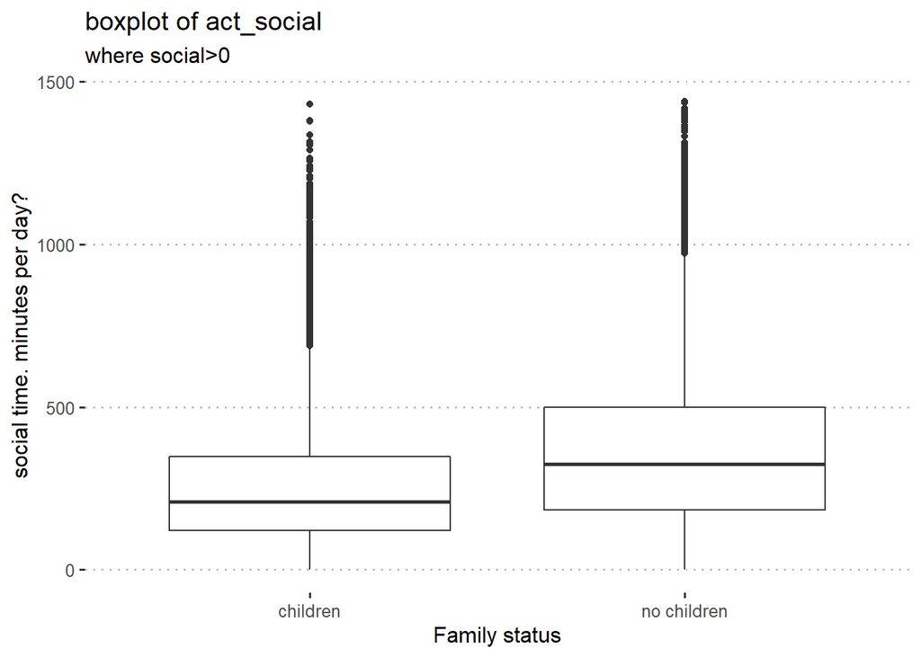

```r
time2 %>%
  filter(ACT_SOCIAL>0) %>%
  ggplot(aes(kids,ACT_SOCIAL)) + geom_boxplot() +
  ggtitle(label="boxplot of act_social", subtitle="where social>0") +
  ylab("social time. minutes per day?") +
  xlab("Family status")
```

This boxplot shows the distribution of minutes spent in social time, excluding respondant who reported 0 social time.

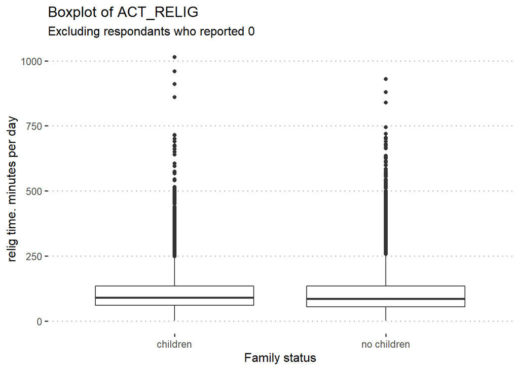

```r
time2 %>%
  filter(ACT_RELIG > 0) %>%
  ggplot(aes(kids,ACT_RELIG)) + geom_boxplot() +
  ggtitle(label="Boxplot of ACT_RELIG", subtitle="Excluding respondants who reported 0") +
  ylab("relig time. minutes per day") +
  xlab("Family status")
```

This is the distribution of reported time spent enaged in religious activities by people who reported more than 0 minutes per day engaged in religious activities.

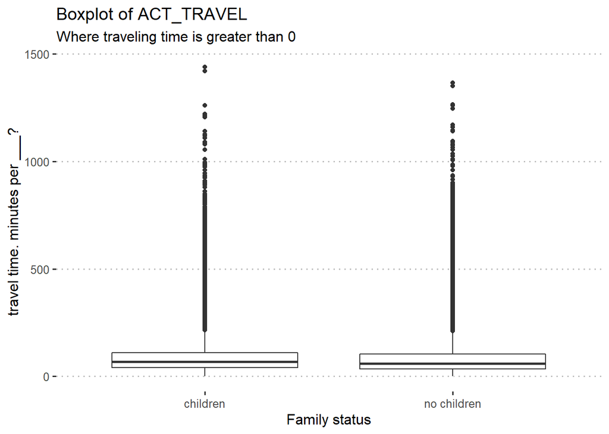

```r
time2 %>%  filter(ACT_TRAVEL>0) %>%
  ggplot(aes(kids,ACT_TRAVEL)) + geom_boxplot() +
  ggtitle(label="Boxplot of ACT_TRAVEL", subtitle="Where traveling time is greater than 0") +
  ylab("travel time. minutes per ___?") +
  xlab("Family status")
```

There are a lot of outliers in this boxplot of ACT_TRAVEL time between those with children and those without. . How much time can one really travel in a day?

#kids & work#

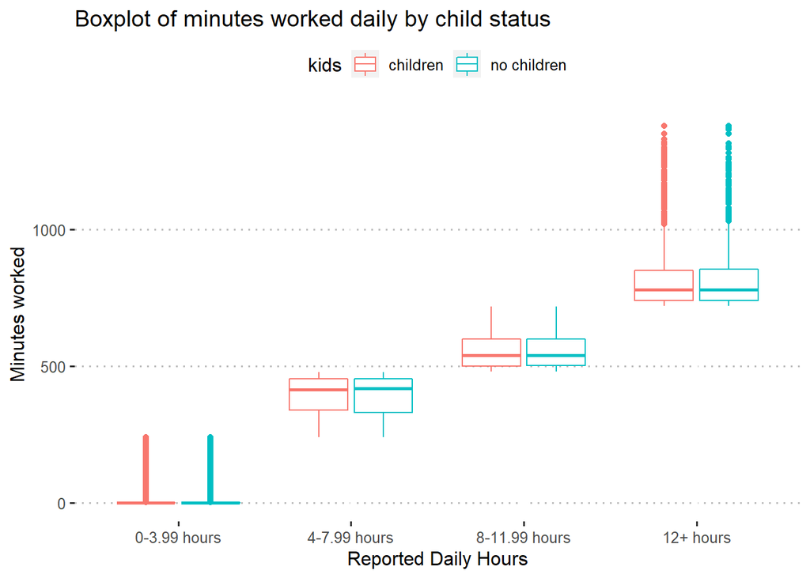

```r
time2 %>%
  ggplot(aes(x=work_time_bins, y=ACT_WORK)) + geom_boxplot(aes(color=kids)) + ggtitle("Boxplot of minutes worked daily by child status") + xlab('Reported Daily Hours') + ylab('Minutes worked')
```

```r
time2 %>%
  group_by(kids, work_time_bins) %>%
  summarize(n = n(), mean_work_minutes = mean(ACT_WORK))
```

```
## # A tibble: 8 x 4
## # Groups:   kids [2]
##   kids        work_time_bins     n mean_work_minutes
##   <fct>       <fct>          <int>             <dbl>
## 1 children    0-3.99 hours   56277             13.1
## 2 children    4-7.99 hours   12238            392.
## 3 children    8-11.99 hours  14405            556.
## 4 children    12+ hours       1863            816.
## 5 no children 0-3.99 hours   76793              9.02
## 6 no children 4-7.99 hours   11784            391.
## 7 no children 8-11.99 hours  14482            557.
## 8 no children 12+ hours       2024            817.
```

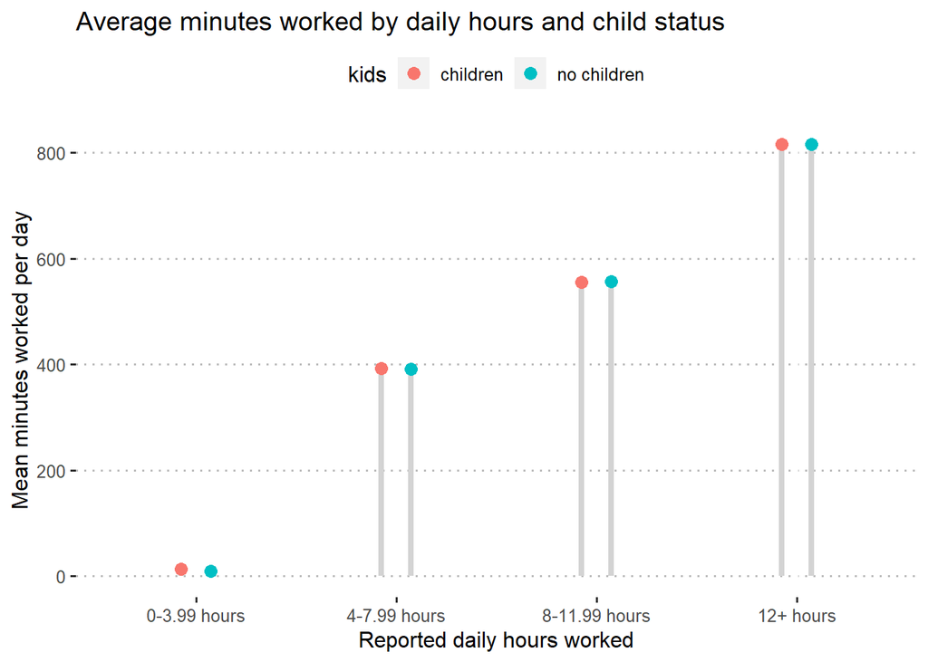

```r
time2 %>%
  group_by(kids, work_time_bins) %>%
  summarize(n = n(), mean_work_minutes = mean(ACT_WORK)) %>%
  ggplot(aes(x=work_time_bins, y=mean_work_minutes)) +
  geom_linerange(aes(x=work_time_bins, ymin=0, ymax=mean_work_minutes, group=kids),
                 color="lightgray",
                 position=position_dodge(0.3),
                 size=1.5) +
  geom_point(aes(color=kids), position=position_dodge(0.3), size=3) +
  theme_pubclean() +
  ggtitle("Average minutes worked by daily hours and child status") +
  ylab("Mean minutes worked per day") + xlab("Reported daily hours worked")
```

# kids & Travel

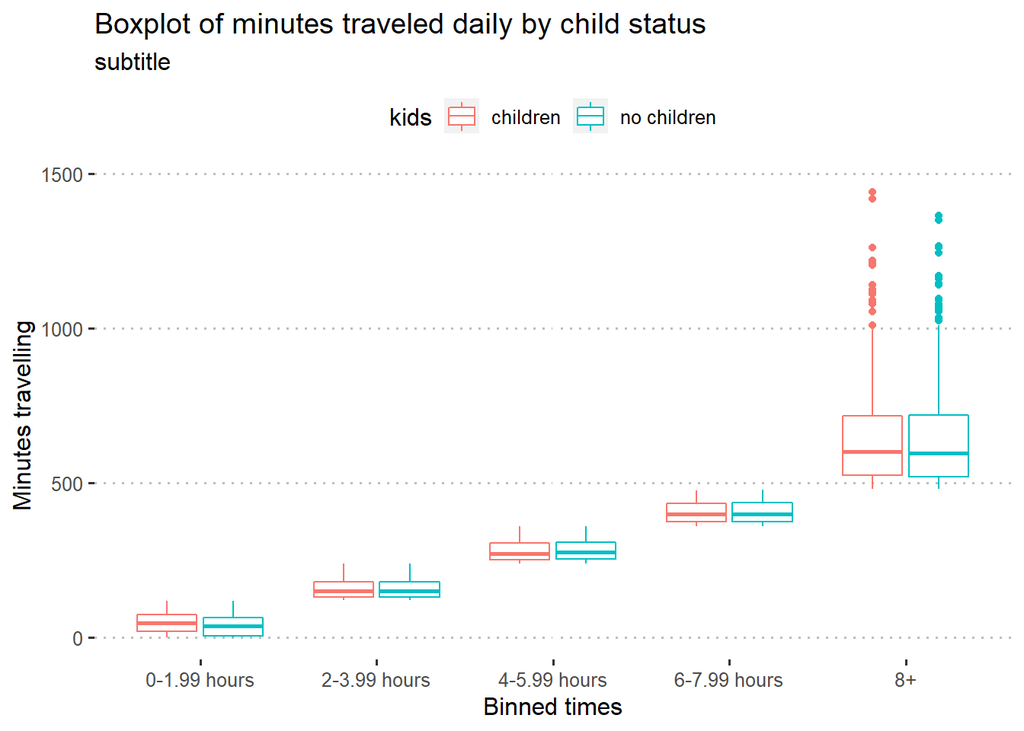

```r
time2  %>%
  ggplot(aes(x=travel_time_bins, y=ACT_TRAVEL)) + geom_boxplot(aes(color=kids)) + ggtitle(label="Boxplot of minutes traveled daily by child status", subtitle="subtitle") + xlab('Binned times') + ylab('Minutes travelling')
```

```r
## because there are so many data points greater than full-time traveling, it's hard to compre the lows and the highs.

time2 %>%
  group_by(kids, travel_time_bins) %>%
  summarize(n = n(), mean_travel_minutes = mean(ACT_TRAVEL))
```

```
## # A tibble: 10 x 4
## # Groups:   kids [2]
##    kids        travel_time_bins     n mean_travel_minutes
##    <fct>       <fct>            <int>               <dbl>
##  1 children    0-1.99 hours     67752                48.8
##  2 children    2-3.99 hours     14074               156.
##  3 children    4-5.99 hours      1981               280.
##  4 children    6-7.99 hours       537               406.
##  5 children    8+                 439               645.
##  6 no children 0-1.99 hours     87680                40.5
##  7 no children 2-3.99 hours     13973               156.
##  8 no children 4-5.99 hours      2190               282.
##  9 no children 6-7.99 hours       670               405.
## 10 no children 8+                 570               640.
```

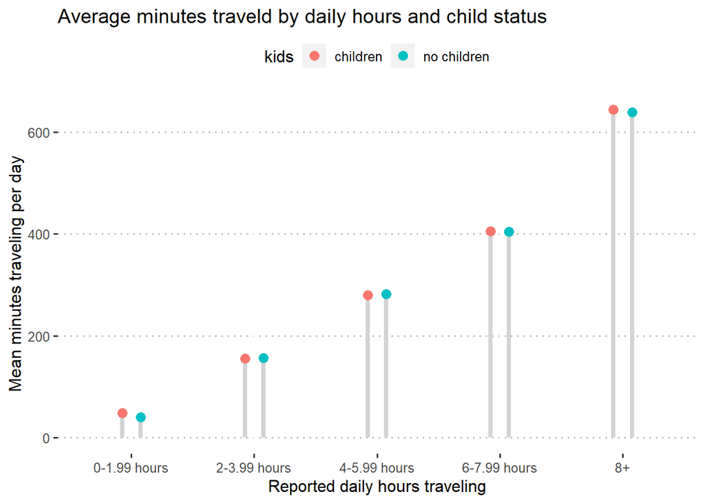

```r
time2 %>%
  group_by(kids, travel_time_bins) %>%
  summarize(n = n(), mean_travel_minutes = mean(ACT_TRAVEL)) %>%
  ggplot(aes(x=travel_time_bins, y=mean_travel_minutes)) +
  geom_linerange(aes(x=travel_time_bins, ymin=0, ymax=mean_travel_minutes, group=kids),
                 color="lightgray",
                 position=position_dodge(0.3),
                 size=1.5) +
  geom_point(aes(color=kids), position=position_dodge(0.3), size=3) +
  theme_pubclean() +
  ggtitle("Average minutes traveld by daily hours and child status") +
  ylab("Mean minutes traveling per day") + xlab("Reported daily hours traveling")
```

Our boxplot shows how the data is distributed across the time spent. Our second box seems to indicate that family with children report slightly more time spent travelling than the no children group.

#kids & religious#

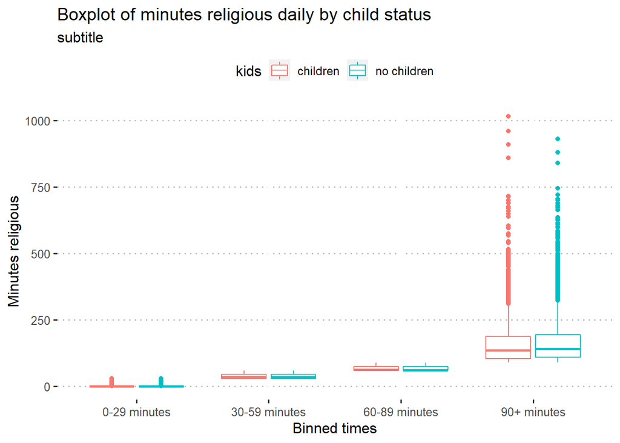

```r
time2  %>%
  ggplot(aes(x=relig_time_bins, y=ACT_RELIG)) + geom_boxplot(aes(color=kids)) + ggtitle(label="Boxplot of minutes religious daily by child status", subtitle="subtitle") + xlab('Binned times') + ylab('Minutes religious')
```

```r
time2 %>%
  group_by(kids, relig_time_bins) %>%
  summarize(n = n(), mean_relig_minutes = mean(ACT_RELIG))
```

```
## # A tibble: 8 x 4
## # Groups:   kids [2]
##   kids        relig_time_bins     n mean_relig_minutes
##   <fct>       <fct>           <int>              <dbl>
## 1 children    0-29 minutes    76874              0.188
## 2 children    30-59 minutes     979             38.5
## 3 children    60-89 minutes    2355             67.7
## 4 children    90+ minutes      4575            162.
## 5 no children 0-29 minutes    92786              0.248
## 6 no children 30-59 minutes    1877             37.7
## 7 no children 60-89 minutes    3665             67.2
## 8 no children 90+ minutes      6755            168.
```

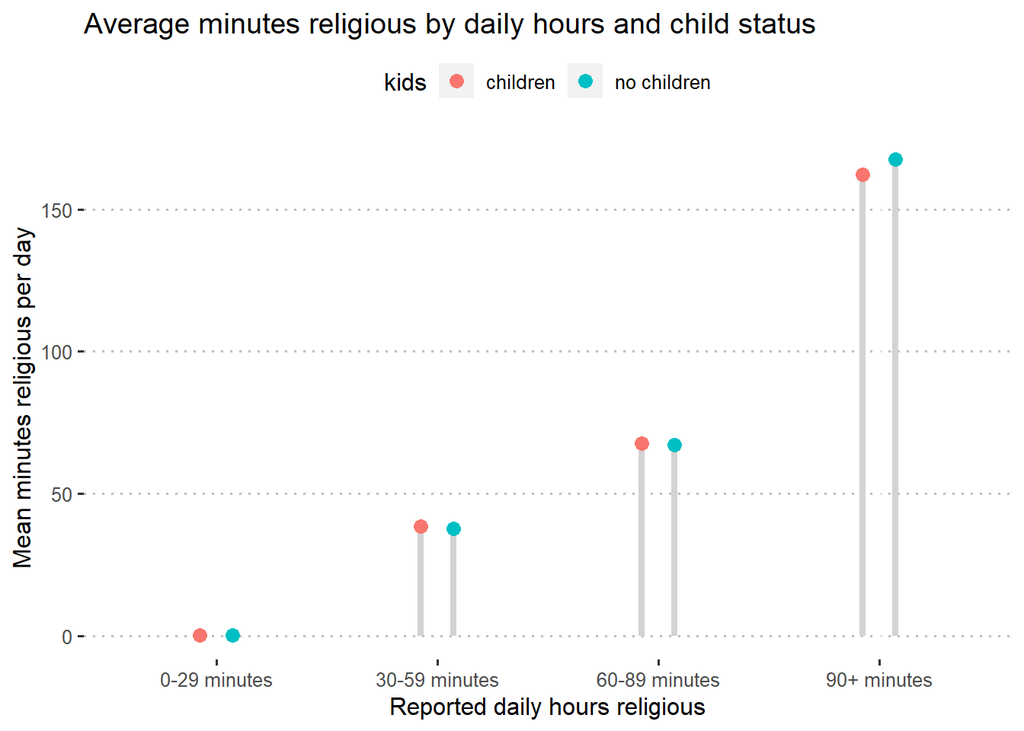

```r
time2 %>%
  group_by(kids, relig_time_bins) %>%
  summarize(n = n(), mean_relig_minutes = mean(ACT_RELIG)) %>%
  ggplot(aes(x=relig_time_bins, y=mean_relig_minutes)) +
  geom_linerange(aes(x=relig_time_bins, ymin=0, ymax=mean_relig_minutes, group=kids),
                 color="lightgray",
                 position=position_dodge(0.3),
                 size=1.5) +
  geom_point(aes(color=kids), position=position_dodge(0.3), size=3) +
  theme_pubclean() +
  ggtitle("Average minutes religious by daily hours and child status") +
  ylab("Mean minutes religious per day") + xlab("Reported daily hours religious")
```

The boxplot here is interesting to us in that there are a lot of possible outlier data above the 90 minuets a day mark. Perhaps this catagory would be better served by adding another block of time at two hours or above? Again, both plots show roughly equal time spent between those with and without children, except in the 90+ minute block, which shows a higher mean for those with no children. #kids & social time#

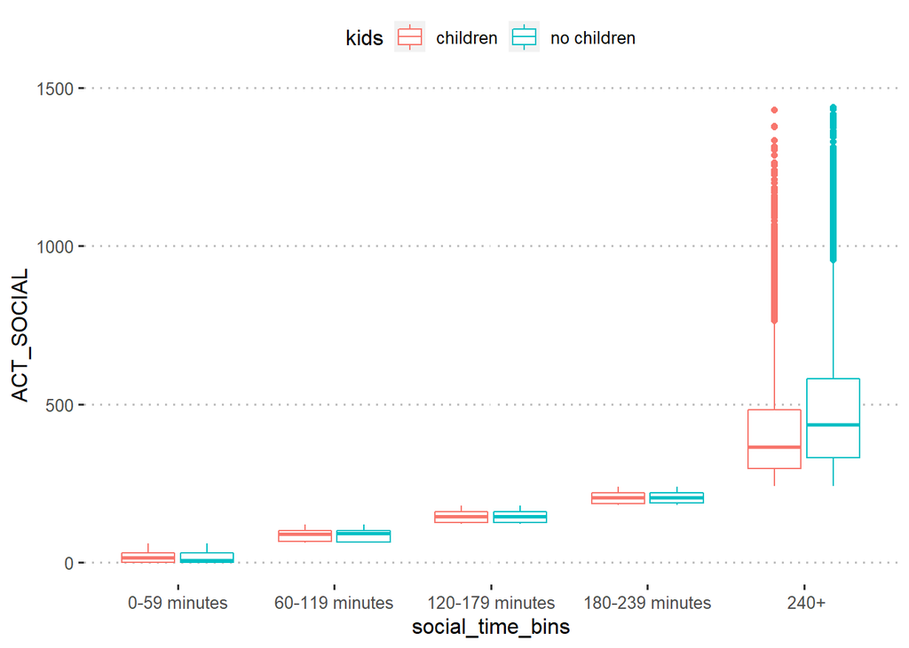

```r
time2  %>%
  ggplot(aes(x=social_time_bins, y=ACT_SOCIAL)) + geom_boxplot(aes(color=kids))
```

```r
time2 %>%
  group_by(kids, social_time_bins) %>%
  summarize(n = n(), mean_social_minutes = mean(ACT_SOCIAL))
```

```
## # A tibble: 10 x 4
## # Groups:   kids [2]
##    kids        social_time_bins      n mean_social_minutes
##    <fct>       <fct>             <int>               <dbl>
##  1 children    "0-59 minutes"    11472                17.8
##  2 children    "60-119 minutes"  12401                84.0
##  3 children    "120-179 minutes" 13456               143.
##  4 children    "180-239 minutes" 11696               204.
##  5 children    " 240+"           35758               407.
##  6 no children "0-59 minutes"     7642                16.1
##  7 no children "60-119 minutes"   8005                84.2
##  8 no children "120-179 minutes" 11108               143.
##  9 no children "180-239 minutes" 11575               205.
## 10 no children " 240+"           66753               471.
```

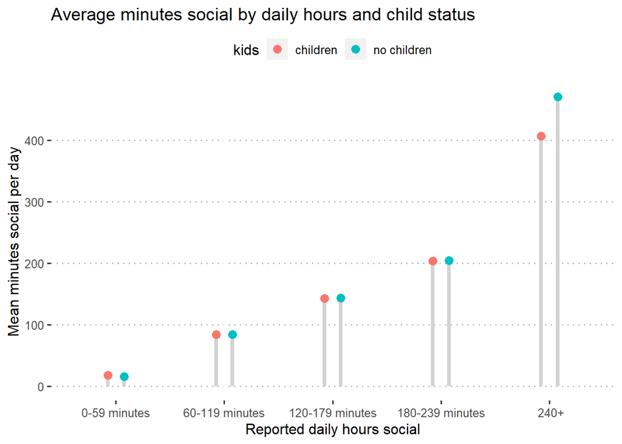

```r
time2 %>%
  group_by(kids, social_time_bins) %>%
  summarize(n = n(), mean_social_minutes = mean(ACT_SOCIAL)) %>%
  ggplot(aes(x=social_time_bins, y=mean_social_minutes)) +
  geom_linerange(aes(x=social_time_bins, ymin=0, ymax=mean_social_minutes, group=kids),
                 color="lightgray",
                 position=position_dodge(0.3),
                 size=1.5) +
  geom_point(aes(color=kids), position=position_dodge(0.3), size=3) +
  theme_pubclean() +
  ggtitle("Average minutes social by daily hours and child status") +
  ylab("Mean minutes social per day") + xlab("Reported daily hours social")
```

These plots are about time spent in social activities between those with and without children. The large number of outliers indicate to us that maybe another time block above four hours might be in order. In four of the catagories the mean time spent in social activity the mean minutes are roughly equal, but in the catagory of four or more hours per day there is a clear difference in the means between those with and those without children. We should probably not be surprised by this.

### Relationships between times

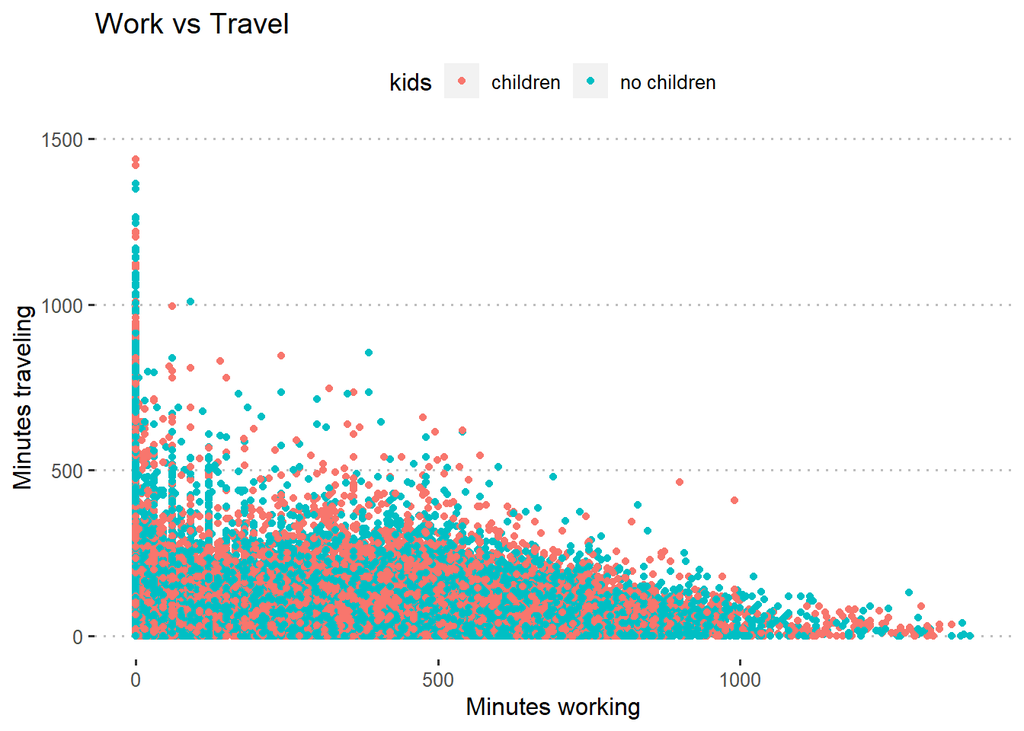

```r
# this is a very ugly plot! too many data points!!!
time2 %>%  ggplot(aes(x=ACT_WORK, y=ACT_TRAVEL, color = kids)) + geom_point() + ggtitle("Work vs Travel") +ylab("Minutes traveling") + xlab("Minutes working")
```

This plot is not good. There are twoo many data points too closely packed together. But it attempts to show a relation between minutes spent traveling and minutes spent working.

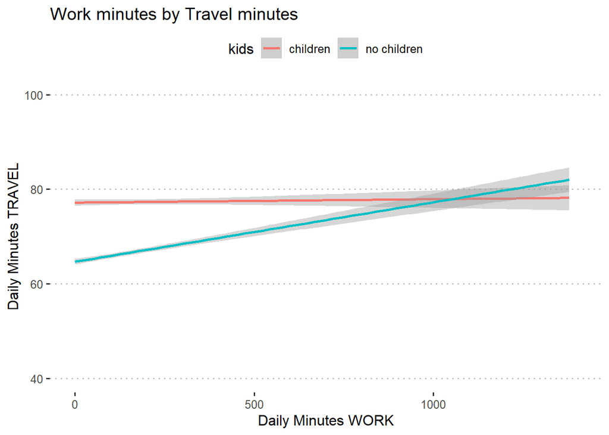

```r
time2 %>%  ggplot(aes(x=ACT_WORK, y=ACT_TRAVEL, color = kids)) +
  geom_smooth(method=lm) +
  ggtitle(label="Work minutes by Travel minutes") +
  xlab("Daily Minutes WORK") + ylab("Daily Minutes TRAVEL") + coord_cartesian(ylim=c(40,100),xlim=c(0,1400))
```

By using a regression line on our data, we might be able to better estimate how respondants use their time and look for signs of interaction or correlatoin between our variables. In this plot we see that respondans with children report about the same amount of travel time as time spent working increases. But for respondants with no children, there is a steeper slope indicating that more time working might correlate to more time spent travelling.

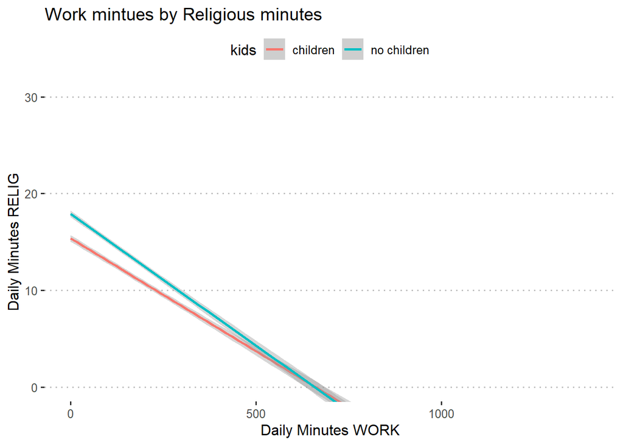

```r
time2 %>%  ggplot(aes(x=ACT_WORK, y=ACT_RELIG, color = kids)) +
  geom_smooth(method=lm) +
  ggtitle(label="Work mintues by Religious minutes") +
  xlab("Daily Minutes WORK") + ylab("Daily Minutes RELIG") + coord_cartesian(ylim=c(0,30),xlim=c(0,1400))
```

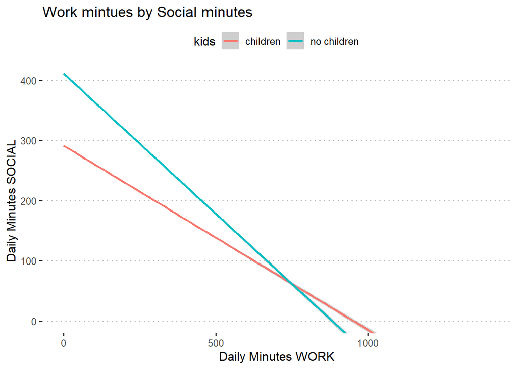

```r
time2 %>%  ggplot(aes(x=ACT_WORK, y=ACT_SOCIAL, color = kids)) +
  geom_smooth(method=lm) +
  ggtitle(label="Work mintues by Social minutes") +
  xlab("Daily Minutes WORK") + ylab("Daily Minutes SOCIAL") + coord_cartesian(ylim=c(0,400),xlim=c(0,1400))
```

Among both respondants with children and those without, as minutes work increases, the amount of social time decreases.

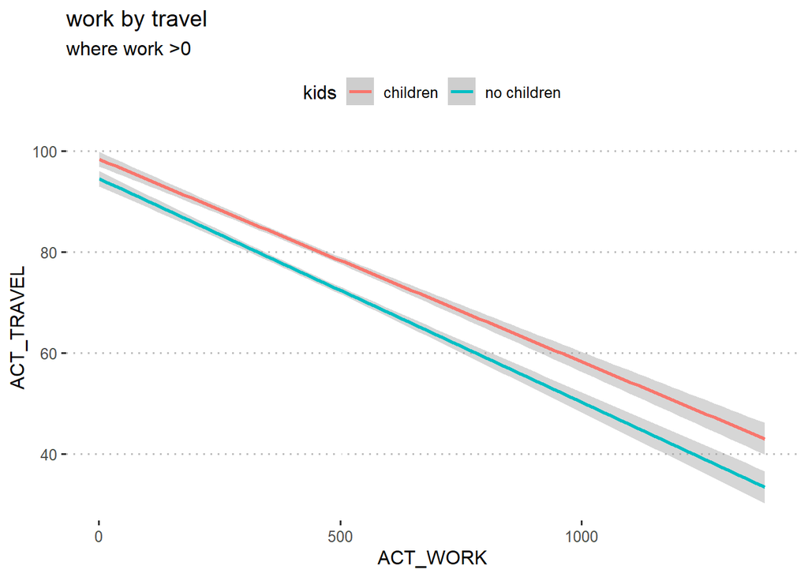

```r
# the variable time three only includes the data where the respondent
# indicated that they work
time3 <- time2 %>% filter(ACT_WORK>0)
time3 %>%
  ggplot(aes(x=ACT_WORK, y=ACT_TRAVEL, color = kids)) +
  geom_smooth(method=lm) +
  ggtitle(label="work by travel", subtitle="where work >0")
```

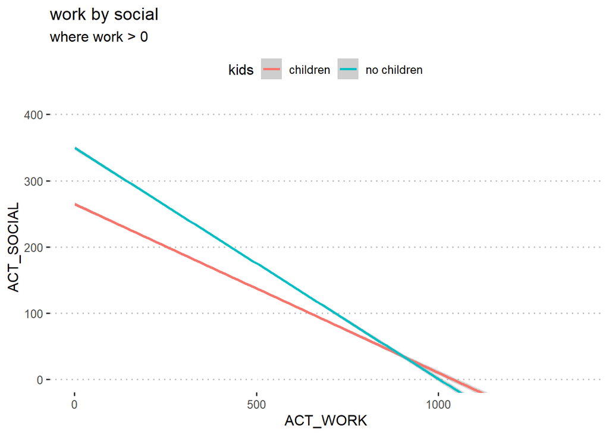

```r
time3 %>%
  ggplot(aes(x=ACT_WORK, y=ACT_SOCIAL, color=kids)) +
  geom_smooth(method=lm) +
  ggtitle(label="work by social", subtitle="where work > 0") + coord_cartesian(ylim=c(0,400))
```

Among people who reported working, the cohort of no children appear to have higher mean social minutes than thir counterpart.

### Possible correlations?

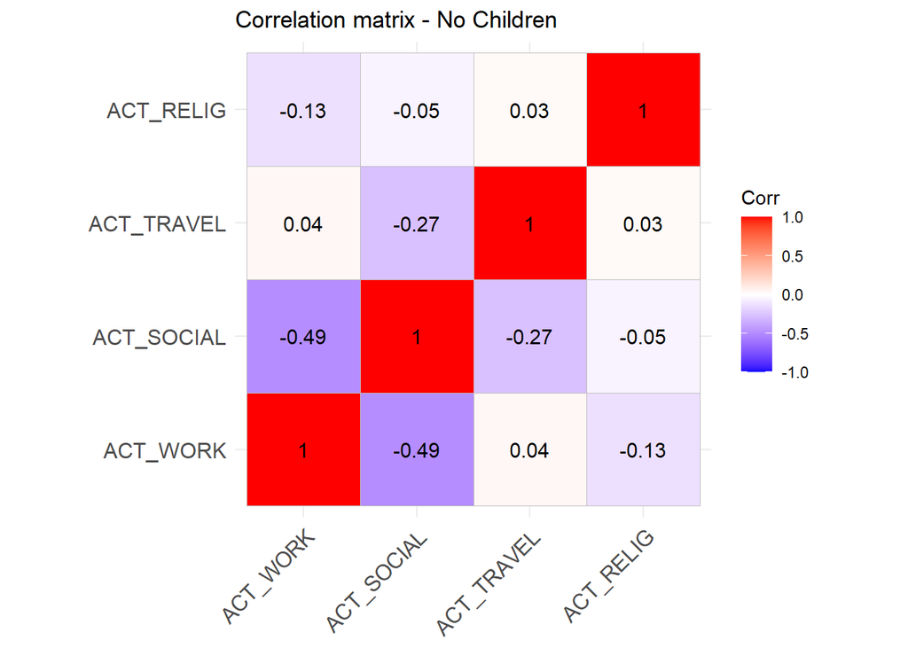

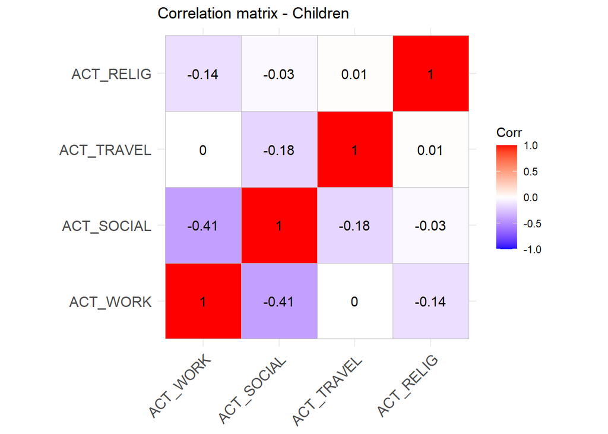